# What Makes a Pokemon Legendary

Bilsay Varcin

April 2, 2020

## Introduction

In the world of Pokemon academia, one name towers above any other - Professor Samuel Oak. While his colleague Professor Elm specializes in Pokemon evolution, Oak has dedicated his career to understanding the relationship between Pokemon and their human trainers. A former trainer himself, the professor has first-hand experience of how obstinate Pokemon can be - particularly when they hold legendary status.

For his latest research project, Professor Oak has decided to investigate the defining characteristics of legendary Pokemon to improve our understanding of their temperament. Hearing of our expertise in classification problems, he has enlisted us as the lead researchers.

Our journey begins at the professor’s research lab in Pallet Town, Kanto. The first step is to open up the Pokedex, an encyclopaedic guide to 801 Pokemon from all seven generations.

| pokedex_number | name | attack | defense | height_m | hp | percentage_male | sp_attack | sp_defense | speed | type | weight_kg | generation | is_legendary |
| --- | --- | --- | --- | --- | --- | --- | --- | --- | --- | --- | --- | --- | --- |
| 1 | Bulbasaur | 49 | 49 | 0.7 | 45 | 88.1 | 65 | 65 | 45 | grass | 6.9 | 1 | 0 |
| 2 | Ivysaur | 62 | 63 | 1.0 | 60 | 88.1 | 80 | 80 | 60 | grass | 13.0 | 1 | 0 |
| 3 | Venusaur | 100 | 123 | 2.0 | 80 | 88.1 | 122 | 120 | 80 | grass | 100.0 | 1 | 0 |
| 4 | Charmander | 52 | 43 | 0.6 | 39 | 88.1 | 60 | 50 | 65 | fire | 8.5 | 1 | 0 |
| 5 | Charmeleon | 64 | 58 | 1.1 | 58 | 88.1 | 80 | 65 | 80 | fire | 19.0 | 1 | 0 |
| 6 | Charizard | 104 | 78 | 1.7 | 78 | 88.1 | 159 | 115 | 100 | fire | 90.5 | 1 | 0 |

## How many Pokemon are legendary?

After browsing the Pokedex, we can see several variables that could feasibly explain what makes a Pokemon legendary. We have a series of numerical fighter stats - attack, defense, speed and so on - as well as a categorization of Pokemon type (bug, dark, dragon, etc.). is_legendary is the binary classification variable we will eventually be predicting, tagged 1 if a Pokemon is legendary and 0 if it is not.

Before we explore these variables in any depth, let’s find out how many Pokemon are legendary out of the 801 total, using the handy count() function from the dplyr package.

| is_legendary | n | prop |
| --- | --- | --- |
| 0 | 731 | 91.3% |
| 1 | 70 | 8.7% |

## Legendary Pokemon by height and weight

We now know that there are 70 legendary Pokemon - a sizable minority at 9% of the population! Let’s start to explore some of their distinguishing characteristics.

First of all, we’ll plot the relationship between height_m and weight_kg for all 801 Pokemon, highlighting those that are classified as legendary. We’ll also add conditional labels to the plot, which will only print a Pokemon’s name if it is taller than 7.5m or heavier than 600kg.

[figure not shown]

## Legendary Pokemon by type

It seems that legendary Pokemon are generally heavier and taller, but with many exceptions. For example, Onix (Gen 1), Steelix (Gen 2) and Wailord (Gen 3) are all extremely tall, but none of them have legendary status. There must be other factors at play.

We will now look at the effect of a Pokemon’s type on its legendary/non-legendary classification. There are 18 possible types, ranging from the common (Grass / Normal / Water) to the rare (Fairy / Flying / Ice). We will calculate the proportion of legendary Pokemon within each category, and then plot these proportions using a simple bar chart.

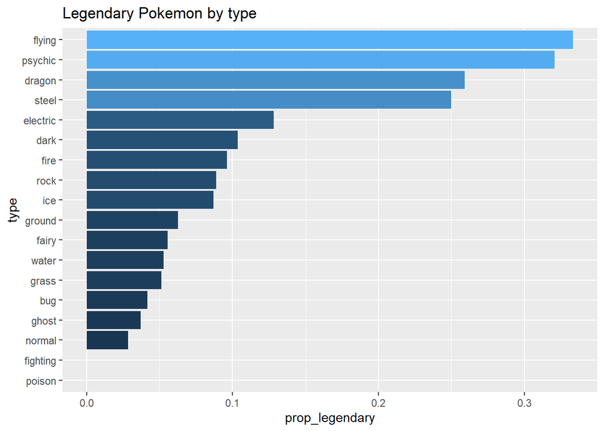

## Legendary Pokemon by fighter stats

There are clear differences between Pokemon types in their relation to legendary status. While more than 30% of flying and psychic Pokemon are legendary, there is no such thing as a legendary poison or fighting Pokemon!

Before fitting the model, we will consider the influence of a Pokemon’s fighter stats (attack, defense, etc.) on its status. Rather than considering each stat in isolation, we will produce a boxplot for all of them simultaneously using the facet_wrap() function.

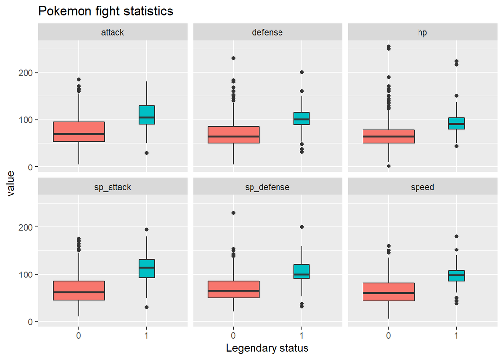

## Create a training/test split

As we might expect, legendary Pokemon outshine their ordinary counterparts in all fighter stats. Although we haven’t formally tested a difference in means, the boxplots suggest a significant difference with respect to all six variables. Nonetheless, there are a number of outliers in each case, meaning that some legendary Pokemon are anomalously weak.

We have now explored all of the predictor variables we will use to explain what makes a Pokemon legendary. Before fitting our model, we will split the pokedex into a training set (pokedex_train) and a test set (pokedex_test). This will allow us to test the model on unseen data.

## Fit a decision tree

Now we have our training and test sets, we can go about building our classifier. But before we fit a random forest, we will fit a simple **classification decision tree**. This will give us a baseline fit against which to compare the results of the random forest, as well as an informative graphical representation of the model.

Here, and also in the random forest, we will omit incomplete observations by setting the na.action argument to na.omit. This will remove a few Pokemon with missing values for height_m and weight_kg from the training set. Remember the warning messages when we made our height/weight plot in Task 3? These are the Pokemon to blame!

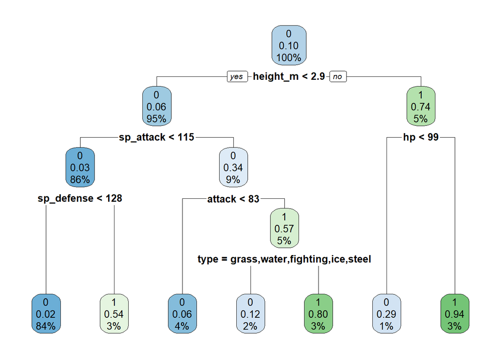

## Fit a random forest

However, decision trees are unstable and sensitive to small variations in the data. It therefore makes sense to fit a **random forest** - an ensemble method that averages over several decision trees all at once. This should give us a more robust model that classifies Pokemon with greater accuracy.

```
##
## Call:
##  randomForest(formula = is_legendary ~ attack + defense + height_m +      hp + sp_attack + sp_defense + speed + type + weight_kg, data = pokedex_train,      importance = TRUE, na.action = na.omit)
##                Type of random forest: classification
##                      Number of trees: 500
## No. of variables tried at each split: 3
##
##         OOB estimate of  error rate: 6.18%
## Confusion matrix:
##     0  1 class.error
## 0 419  5  0.01179245
## 1  24 21  0.53333333
```

## Assess model fit

In order to allow direct comparison with the decision tree, we will plot the ROC curves for both models using the ROCR package, which will visualize their true positive rate (TPR) and false positive rate (FPR) respectively. The closer the curve is to the top left of the plot, the higher the area under the curve (AUC) and the better the model.

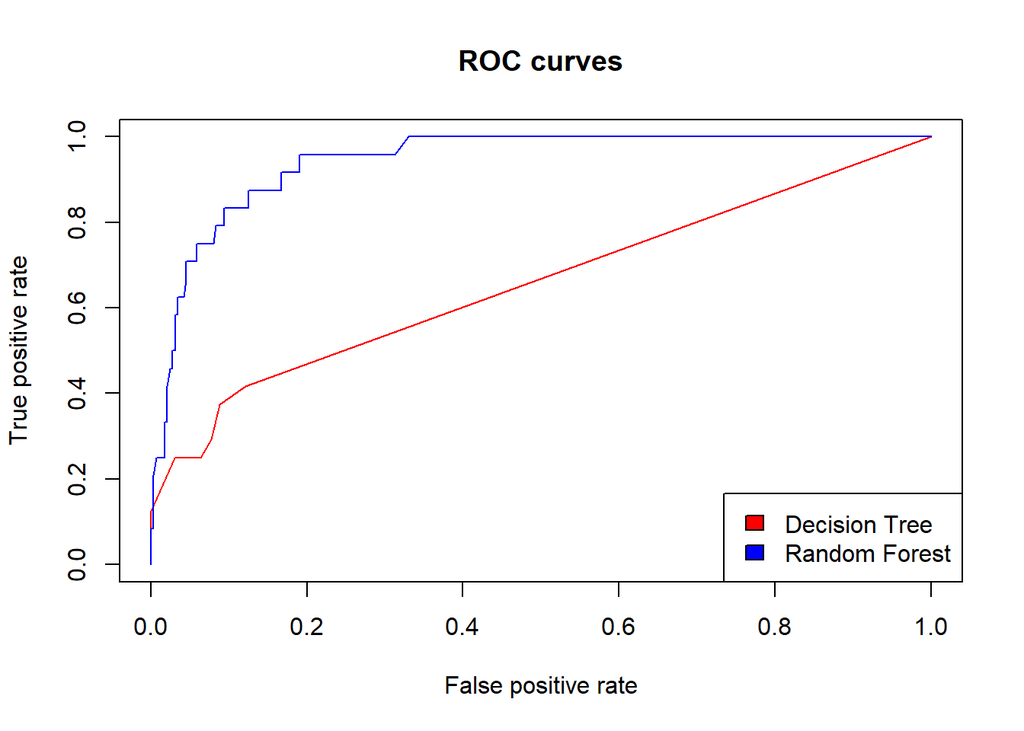

## Analyze variable importance

Note that a random forest returns two measures of variable importance:

MeanDecreaseAccuracy - how much the model accuracy suffers if you leave out a particular variable MeanDecreaseGini - the degree to which a variable improves the probability of an observation being classified one way or another (i.e. ‘node purity’). Together, these two measures will allow us to answer our original research question - what makes a Pokemon legendary?

```
##                   0         1 MeanDecreaseAccuracy MeanDecreaseGini
## attack     6.057177 10.090444            10.943867         5.433364
## defense    3.447970  7.777740             7.157058         4.974372
## height_m   1.970646 11.699348             9.330406        10.922078
## hp         6.684172 15.982089            14.575125         7.976519
## sp_attack  1.625093 19.743620            13.648709        12.835879
## sp_defense 4.799102 11.611696            10.195838         7.860335
## speed      4.346961 20.939571            15.937450        10.787632
## type       4.389508  4.247149             5.735069         9.863498
## weight_kg  7.811610  9.608579            11.100255        10.670094
```

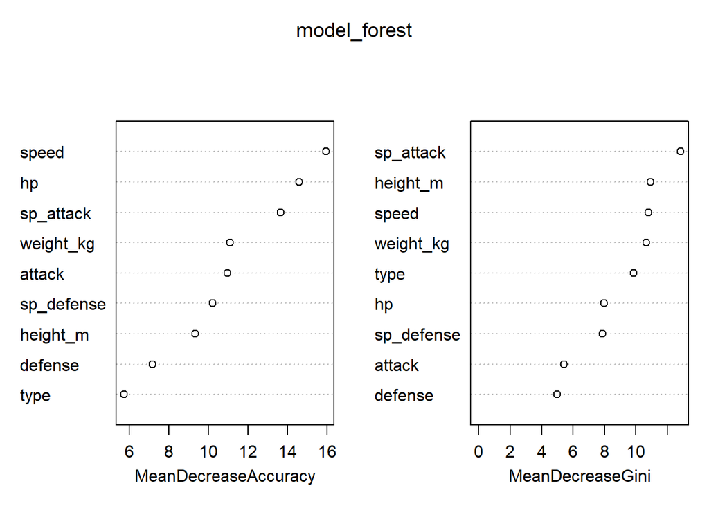

```
##            MeanDecreaseAccuracy MeanDecreaseGini
## attack                10.943867         5.433364
## defense                7.157058         4.974372
## height_m               9.330406        10.922078
## hp                    14.575125         7.976519
## sp_attack             13.648709        12.835879
## sp_defense            10.195838         7.860335
## speed                 15.937450        10.787632
## type                   5.735069         9.863498
## weight_kg             11.100255        10.670094
```